# 2020-09-01_Projet_M5

Camille COHEN

le 01 September, 2020

# 1 DU-Bii 2020 : Examen final Modules 4 et 5

Nous allons vous faire faire un analyse simple, de données de reséquençage d’un génome bactérien. Les données sont issues de cet article : “Complete Genome Sequences of 13 Bacillus subtilis Soil Isolates for Studying Secondary Metabolite Diversity” (doi:10.1128/MRA.01406-19)

## 1.1 Objectif :

Nous allons vous demander de faire une première analyse de ces données, et de nous la rendre sous la forme d’un rapport qui trace l’ensemble des étapes suivies. Ce rapport devra être mis à nôtre disposition dans un dépôt public GitHub. Les analyses devront pouvoir être rejouées sur le cluster de l’IFB.

Données d’entrées : - Identifiant du run : SRR10390685 - Génome de référence : NC_000964 - Gff https://ftp.ncbi.nlm.nih.gov/genomes/all/GCF/000/009/045/GCF_000009045.1_ASM904v1/GCF_000009045.1_ASM904v1_genomic.gff.gz - Fasta https://ftp.ncbi.nlm.nih.gov/genomes/all/GCF/000/009/045/GCF_000009045.1_ASM904v1/GCF_000009045.1_ASM904v1_genomic.fna.gz

## 1.2 Analyse :

Voici le dossier contenant les données et les résultats obtenus pendant l’analyse :

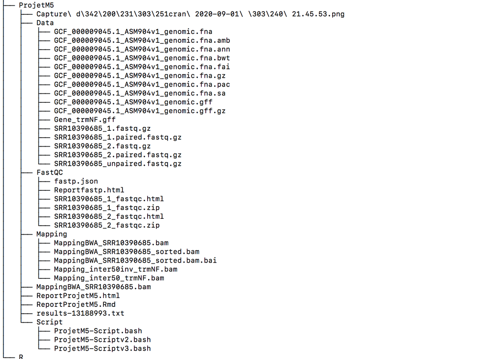

### 1.2.1 Téléchargement des données depuis les banques publiques

Pour le génome de référence, le fichier fasta et gff vont être téléchargé avec l’outil *wget* qui permet de récupérer les données à partir d’un URL donné.

Pour pouvoir par la suite utiliser le fichier fasta et le gff, il faut dézipper les fichiers avec l’outil *gzip*

Pour récupérer les données de séquencage, on a besoin du module *sra-tools* qui permet de récupérer les données inscrites dans la base de données SRA. Pour cela on utilise l’outil *faster-dump*. Et je zippe les fichiers fastq afin qu’ils prennent moins de place.

### 1.2.2 Contrôle qualité des données brutes (reads)

Pour le contrôle qualité on utilise FastQC.

#### 1.2.2.1 La qualité des bases vous paraît-elle satisfaisante ? Pourquoi ?

[Cliquer ici pour voir le Rapport FastQC](https://rstudio.cluster.france-bioinformatique.fr/file_show?path=%2Fshared%2Fmfs%2Fdata%2Fhome%2Fccohen%2FProjetM5%2FFastQC%2FSRR10390685_2_fastqc.html)

La qualité des reads semblent correctes déjà par la longueur des reads entre 130 et 150pb , la qualité par séquence ne depasse la zone verte , ce qui indique peut de dégradation des reads, et il y a peu de N dans les reads obtenus.

### 1.2.3 Nettoyage des reads

Pour nettoyer on filtre la qualité des reads et on retire les adaptateurs de séquencage , ou trimmer les séquences, avec *fastp*.

[Cliquer ici pour voir le Rapport Fastp](https://rstudio.cluster.france-bioinformatique.fr/file_show?path=%2Fshared%2Fmfs%2Fdata%2Fhome%2Fccohen%2FProjetM5%2FFastQC%2FReportfastp.html)

### 1.2.4 Alignement des reads contre le génome de reférence

Pour le mapping on utilise le mappeur *BWA*

#### 1.2.4.1 Quel est le % de reads pairés alignés ?

le % de reads alignés est de 94.49%

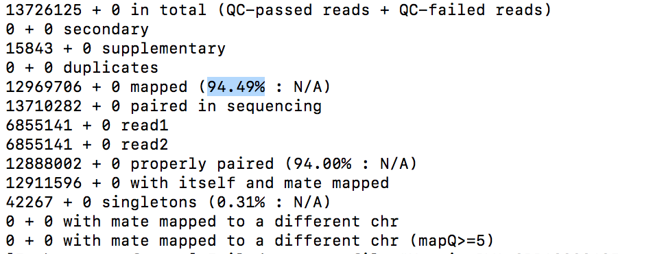

Flagstats

### 1.2.5 Extraire dans un fichier BAM les reads chevauchant à au moins 50% le gène trmNF

Pour extraire cette donnée nous devons tout d’abord récupérer la position du gène “trmNF” pour cela on va utiliser tout d’abord *grep* pour récupérer les lignes contenant le nom du gène . On constate que nous avons deux lignes, donc on utilise *awk* pour sélectionner que les lignes dont la colonne 3 contient “gene”.

Ensuite on utilise *intersect* de bedtools qui va nous permettre de connaitre le hcevauchement des reads sur plus de 50% du gène

Pour mon analyse, je trouve 0 reads chevauchant 50% du gène.

### 1.2.6 Logiciels utilisés:

bwa/0.7.17

samtools/1.10

fastp/0.20.0

fastqc/0.11.9

bedtools/2.29.2

sra-tools/2.10.3